# Getting started with the R-package hystReet

Johannes Friedrich

2020-06-12

# 1 Introduction

[hystreet](https://hystreet.com) is a company collecting pedestrains in german cities. After registering you can download the data for free from 19 cities.

# 2 Installation

# 3 API Keys

To use this package, you will first need to get a hystreet API key. To do so, you first need to set up an account on https://hystreet.com/. After that you can request an API key via e-mail. Once your request has been granted, you will find you key in your hystreet account profile.

Now you have three options:

1. Once you have your key, save it as an environment variable for the current session by running the following:

```r
Sys.setenv(HYSTREET_API_TOKEN = "PASTE YOUR API TOKEN HERE")
```

2. Alternatively, you can set it permanently with the help of `usethis::edit_r_environ()` by adding the line to your `.Renviron`:

```
HYSTREET_API_TOKEN = PASTE YOUR API TOKEN HERE
```

3. If you don’t want to save it here, you can input it in each function using the `API_token` parameter.

# 4 Usage

| Function name | Description | Example |
| --- | --- | --- |
| get_hystreet_stats() | request common statistics about the hystreet project | get_hystreet_stats() |
| get_hystreet_locations() | request all qvailable locations | get_hystreet_locations() |
| get_hystreet_station_data() | request data from a stations | get_hystreet_station_data(71) |
| set_hystreet_token() | set your API token | set_hystreet_token(123456789) |

### 4.0.1 Load some statistics

The function ‘get_hystreet_stats()’ summarises the number of available stations and the sum of all counted pedestrians.

```r
library(hystReet)

stats <- get_hystreet_stats()
```

## 4.1 Request all stations

The function ‘get_hystreet_locations()’ requests all available stations of the project.

```r
locations <- get_hystreet_locations()
```

| id | name | city |
| --- | --- | --- |
| 57 | Schlösserstraße | Erfurt |
| 68 | Petersstraße | Leipzig |
| 256 | Kirchgasse (Nord) | Wiesbaden |
| 86 | Löhrstraße (Mitte) | Koblenz |
| 59 | Goethestraße | Frankfurt a.M. |
| 107 | Krahnstraße (Süd) | Osnabrück |
| 206 | Kröpeliner Straße (West) | Rostock |
| 77 | Königstraße (Süd) | Stuttgart |
| 150 | Zeil (Mitte) | Frankfurt a.M. |
| 53 | Schadowstraße (West) | Düsseldorf |

## 4.2 Request data from a specific station

The (probably) most interesting function is ‘get_hystreet_station_data()’. With the hystreetID it is possible to request a specific station. By default, all the data from the current day are received. With the ‘query’ argument it is possible to set the received data more precise: * from: datetime of earliest measurement (default: today 00:00:00:): e.g. “2018-10-01 12:00:00” or “2018-10-01” * to : datetime of latest measurement (default: today 23:59:59): e.g. “2018-12-01 12:00:00” or “2018-12-01” * resoution: Resultion for the measurement grouping (default: hour): “day”, “hour”, “month”, “week”

```r
location_71 <- get_hystreet_station_data(
  hystreetId = 71,
  query = list(from = "2018-12-01", to = "2019-01-01", resolution = "day"))
```

# 5 Some ideas to visualise the data

Let´s see if we can see the most frequent days before christmas … I think it could be saturday ;-). Also nice to see the 24th and 25th of December … holidays in Germany :-).

```r
location_71 <- get_hystreet_station_data(
    hystreetId = 71,
    query = list(from = "2018-12-01", to = "2019-01-01", resolution = "hour"))
```

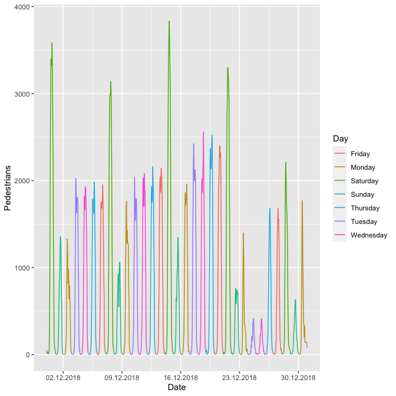

```r
ggplot(location_71$measurements, aes(x = timestamp, y = pedestrians_count, colour = weekdays(timestamp))) +
  geom_path(group = 1) +
  scale_x_datetime(date_breaks = "7 days") +
  scale_x_datetime(labels = date_format("%d.%m.%Y")) +
  labs(x = "Date",
       y = "Pedestrians",
       colour = "Day")
```

## 5.1 Compare different stations

Now let´s compare different stations:

1. Load the data

```r
location_73 <- get_hystreet_station_data(
    hystreetId = 73,
    query = list(from = "2019-01-01", to = "2019-01-31", resolution = "day"))$measurements %>%
  select(pedestrians_count, timestamp) %>%
  mutate(station = 73)

location_74 <- get_hystreet_station_data(
    hystreetId = 74,
    query = list(from = "2019-01-01", to = "2019-01-31", resolution = "day"))$measurements %>%
    select(pedestrians_count, timestamp) %>%
  mutate(station = 74)

data_73_74 <- bind_rows(location_73, location_74)
```

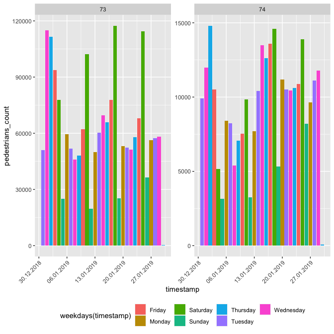

```r
ggplot(data_73_74, aes(x = timestamp, y = pedestrians_count, fill = weekdays(timestamp))) +
  geom_bar(stat = "identity") +
  scale_x_datetime(labels = date_format("%d.%m.%Y")) +
  facet_wrap(~station, scales = "free_y") +
  theme(legend.position = "bottom",
        axis.text.x = element_text(angle = 45, hjust = 1))
```

## 5.2 Highest ratio (pedestrians/day)

Now a little bit of big data analysis. Let´s find the station with the highest pedestrians per day ratio:

```r
hystreet_ids <- get_hystreet_locations()

all_data <- lapply(hystreet_ids[,"id"], function(ID){
  temp <- get_hystreet_station_data(
    hystreetId = ID,
    query = list(from = "2019-01-01", to = today(), resolution = "day"))

    lifetime_count <- temp$statistics$timerange_count
    days_counted <- as.numeric(temp$metadata$latest_measurement_at  - temp$metadata$earliest_measurement_at)

    return(data.frame(
      id = ID,
      station = paste0(temp$city, " (",temp$name,")"),
      ratio = lifetime_count/days_counted))

})

ratio <- bind_rows(all_data)
```

What stations have the highest ratio?

```r
ratio %>%
  top_n(5, ratio) %>%
  arrange(desc(ratio))
```

```
##    id                       station    ratio
## 1 165     München (Kaufingerstraße) 64469.29
## 2 150 Frankfurt a.M. (Zeil (Mitte)) 52520.83
## 3 159  Köln (Schildergasse (Mitte)) 50318.07
## 4  73    München (Neuhauser Straße) 49996.25
## 5 158      Köln (Hohe Straße (Süd)) 39806.93
```

Now let´s visualise the top 10 cities:

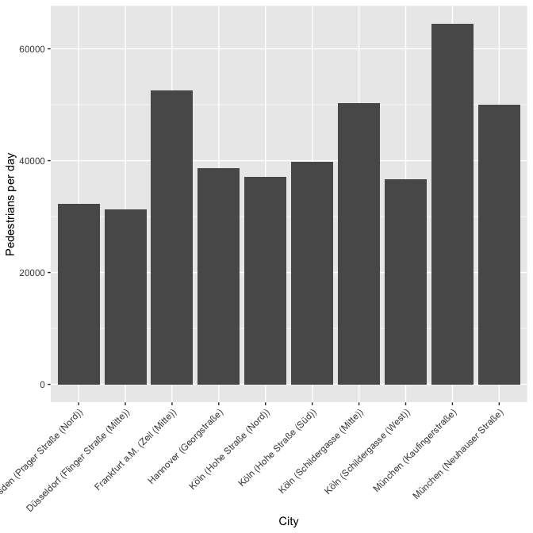

```r
ggplot(ratio %>%
         top_n(10,ratio), aes(station, ratio)) +
  geom_bar(stat = "identity") +
  labs(x = "City",
       y = "Pedestrians per day") +
    theme(legend.position = "bottom",
        axis.text.x = element_text(angle = 45, hjust = 1))
```

### 5.2.1 Corona effects

The Hystreet-API is a great source of analysing the social effects of the Corona pandemic in 2020. Let´s collect all german stations since March 2020 and analyse the pedestrian count until 10th June 2020.

```r
corona_data <- lapply(hystreet_ids[,"id"], function(ID){

    temp <- get_hystreet_station_data(
        hystreetId = ID,
        query = list(from = "2020-03-01", to = "2020-06-10", resolution = "day")
    )

    return(data.frame(
    name = temp$name,
    city = temp$city,
    timestamp = format(as.POSIXct(temp$measurements$timestamp), "%Y-%m-%d"),
    pedestrians_count = temp$measurements$pedestrians_count,
    legend = paste(temp$city, temp$name, sep = " - ")
  ))

})

corona_data_all <- bind_rows(data)
```

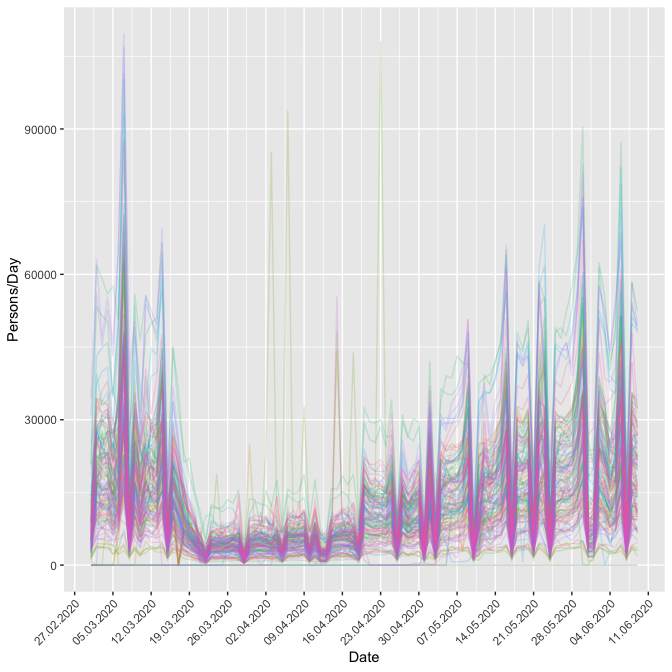

```r
corona_data_all %>%
ggplot(aes(ymd(timestamp), pedestrians_count, colour = legend)) +
geom_line(alpha = 0.2) +
    scale_x_date(labels = date_format("%d.%m.%Y"),
               breaks = date_breaks("7 days")
     ) +
  theme(legend.position = "none",
        legend.title = element_text("Legende"),
         axis.text.x = element_text(angle = 45, hjust = 1)) +
  labs(x = "Date",
       y = "Persons/Day")
```